# Calibrating probabilities for imbalanced classification

A classification model is usually used to predict the probability of an observation belonging to each possible class label. Although a model may be able to predict probabilities, the distribution and behavior of the probabilities may not match the expected distribution of observed probabilities in the training data. This is especially common with complex nonlinear machine learning algorithms that do not directly make probabilistic predictions and instead use approximations. The distribution of the probabilities can be adjusted to better match the expected distribution observed in the data. This adjustment is referred to as calibration

In general,

- LogisticRegression returns well calibrated predictions by default as it directly optimizes log-loss
- Models such as Naive Bayes, which make unrealistic independence assumptions, push probabilities toward 0 and 1
- Maximum margin methods such as boosted trees and boosted stumps push probability mass away from 0 and 1 yielding a characteristic sigmoid shaped distortion in the predicted probabilities
- Other models such as bagged trees do not have these biases and predict well calibrated probabilities

In this POC we experiment with correcting the biased probabilities predicted by learning method: Isotonic Regression

What prompted to do this experiment?

The following plot shows kappa measure plots which is shown as one of our performance output plots. It can be seen that the unacalibrated probabilities of Adaboost (almost all probabbilities between 0.4 to 0.55) and MLP models (almost all probabbilities less than 0.1) are clearly visible and making the plots distorted although there is no wrong in it. This led to study of uncalibrated probabilities generated by few models, reasons and ways to apply calibration on the same.

[figure not shown]

```python
import numpy as np
import pandas as pd
import math
import random
from matplotlib import pyplot as plt
%matplotlib inline
```

### Reading OSRDR approved bank market dataset

```python
bank=pd.read_csv("bank-additional-full.csv",sep=";")
y=bank['y']
y=y.map({"yes": 1, "no":0})
bank.drop(['y','job'],axis=1,inplace=True)
```

```python
from sklearn.model_selection import train_test_split
X_train, X_test, y_train, y_test = train_test_split(bank, y, test_size=0.33, random_state=42)
```

### Exploring the predicted probaility distribution of various classifiers

```python
#Logistic Regression
from sklearn.linear_model import LogisticRegression
logmodel=LogisticRegression(solver='liblinear')
logmodel.fit(pd.get_dummies(X_train),y_train)
log_preds=logmodel.predict_proba(pd.get_dummies(X_test))[:,1]

#Adaboost
from sklearn.ensemble import AdaBoostClassifier
adbmodel=AdaBoostClassifier()
adbmodel.fit(pd.get_dummies(X_train),y_train)
adb_preds=adbmodel.predict_proba(pd.get_dummies(X_test))[:,1]

#SVM
from sklearn.svm import SVC
svcmodel=SVC(probability=True)
svcmodel.fit(pd.get_dummies(X_train),y_train)
svc_preds=svcmodel.predict_proba(pd.get_dummies(X_test))[:,1]

#Random Forests
from sklearn.ensemble import RandomForestClassifier
rfmodel=RandomForestClassifier()
rfmodel.fit(pd.get_dummies(X_train),y_train)
rf_preds=rfmodel.predict_proba(pd.get_dummies(X_test))[:,1]
```

```python
preds_df = pd.DataFrame({"log_preds": log_preds, "adb_preds": adb_preds,
                         "svc_preds": svc_preds, "rf_preds": rf_preds})
preds_df.describe()
```

|  | log_preds | adb_preds | svc_preds | rf_preds |
| --- | --- | --- | --- | --- |
| count | 13593.000000 | 13593.000000 | 13593.000000 | 13593.000000 |
| mean | 0.112770 | 0.470270 | 0.114221 | 0.112406 |
| std | 0.189690 | 0.041081 | 0.121059 | 0.205119 |
| min | 0.000194 | 0.294961 | 0.085736 | 0.000000 |
| 25% | 0.015610 | 0.470046 | 0.086161 | 0.000000 |
| 50% | 0.030730 | 0.476925 | 0.087457 | 0.010000 |
| 75% | 0.103356 | 0.487832 | 0.090486 | 0.110000 |
| max | 0.999998 | 0.529143 | 0.947278 | 0.980000 |

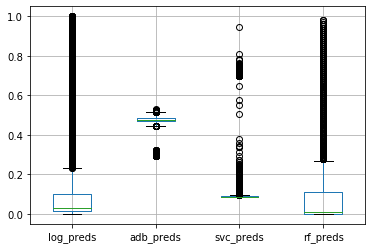

```python
preds_df.boxplot()
```

### Plotting the Reliability Curve

The calibration or Reliability curve works by sorting the probabilities assigned to the records being predicted by the probability reported by the classifier. It then bins the values, and calculates two metrics:

- The **fraction_of_positives** is the percentage of records in the chosen bin which actually belong to the dominant class. This is determined by looking at what values these points are actually assigned in y , and it is the emperical truth.
- The second metric returned, **mean_predicted_value**, is the mean probability of these points belonging to the dominant class reported by the algorithm

If the classifier is forecasting probabilities that are accurate, then we expect the percentage of dominant class classifications and the mean probabilities assigned to the dominant classes in each bin to be close to one another. If it is not doing so accurately, then we will see these two values diverge.

```python
from sklearn.calibration import calibration_curve
svc_fop, svc_mpv = calibration_curve(y_test, svc_preds, n_bins=10, normalize=True)
adb_fop, adb_mpv = calibration_curve(y_test, adb_preds, n_bins=10, normalize=True)
log_fop, log_mpv = calibration_curve(y_test, log_preds, n_bins=10, normalize=True)
rf_fop, rf_mpv = calibration_curve(y_test, rf_preds, n_bins=10, normalize=True)
```

The better calibrated or more reliable a forecast, the closer the points will appear along the main diagonal from the bottom left to the top right of the plot. The position of the points or the curve relative to the diagonal can help to interpret the probabilities; for example:

- Below the diagonal: The model has over-forecast; the probabilities are too large.
- Above the diagonal: The model has under-forecast; the probabilities are too small.

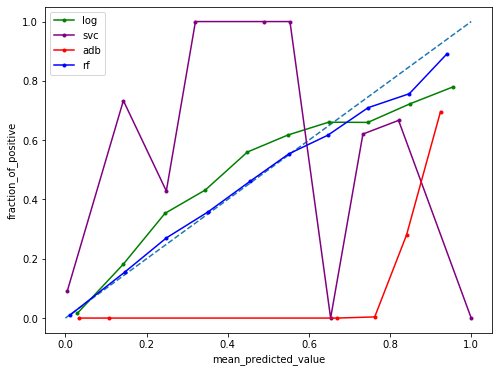

```python
fig = plt.figure( figsize=(8, 6) )
plt.plot([0, 1], [0, 1], linestyle='--')
plt.plot(log_mpv, log_fop, marker='.', label="log", color="green")
plt.plot(svc_mpv, svc_fop, marker='.', label="svc", color="purple")
plt.plot(adb_mpv, adb_fop, marker='.', label="adb", color="red")
plt.plot(rf_mpv, rf_fop, marker='.', label="rf", color="blue")
plt.xlabel("mean_predicted_value")
plt.ylabel("fraction_of_positive")
plt.legend()
plt.show()
```

In the above plot it can be observed that the probability predictions of logistic regression and random forest models are close to optimal but SVM and Adaboost models deviate considerably from the expected

### Apply calibration using sklearn library

```python
from sklearn.calibration import CalibratedClassifierCV

from sklearn.linear_model import LogisticRegression
logmodel=LogisticRegression(solver='liblinear')
logmodel.fit(pd.get_dummies(X_train),y_train)
calibrated = CalibratedClassifierCV(logmodel,method='isotonic', cv="prefit")
calibrated.fit(pd.get_dummies(X_test),y_test)
logc_preds=calibrated.predict_proba(pd.get_dummies(X_test))[:,1]

from sklearn.ensemble import AdaBoostClassifier
adbmodel=AdaBoostClassifier()
adbmodel.fit(pd.get_dummies(X_train),y_train)
calibrated  = CalibratedClassifierCV(adbmodel,method='isotonic', cv="prefit")
calibrated.fit(pd.get_dummies(X_test),y_test)
adbc_preds=calibrated.predict_proba(pd.get_dummies(X_test))[:,1]

from sklearn.svm import SVC
svcmodel=SVC(probability=True)
svcmodel.fit(pd.get_dummies(X_train),y_train)
calibrated  = CalibratedClassifierCV(svcmodel,method='isotonic', cv="prefit")
calibrated.fit(pd.get_dummies(X_test),y_test)
svcc_preds=calibrated.predict_proba(pd.get_dummies(X_test))[:,1]

from sklearn.ensemble import RandomForestClassifier
rfmodel=RandomForestClassifier()
rfmodel.fit(pd.get_dummies(X_train),y_train)
calibrated  = CalibratedClassifierCV(rfmodel,method='isotonic', cv="prefit")
calibrated.fit(pd.get_dummies(X_test),y_test)
rfc_preds=rfmodel.predict_proba(pd.get_dummies(X_test))[:,1]
```

### Plotting the Reliability curves of calibrated probailities

```python
from sklearn.calibration import calibration_curve
svcc_fop, svcc_mpv = calibration_curve(y_test, svcc_preds, n_bins=10, normalize=True)
adbc_fop, adbc_mpv = calibration_curve(y_test, adbc_preds, n_bins=10, normalize=True)
logc_fop, logc_mpv = calibration_curve(y_test, logc_preds, n_bins=10, normalize=True)
rfc_fop, rfc_mpv = calibration_curve(y_test, rfc_preds, n_bins=10, normalize=True)
```

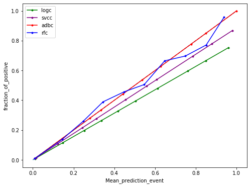

```python
fig = plt.figure( figsize=(8, 6) )
plt.plot([0, 1], [0, 1], linestyle='--')
plt.plot(logc_mpv, logc_fop, marker='.', label="logc", color="green")
plt.plot(svcc_mpv, svcc_fop, marker='.', label="svcc", color="purple")
plt.plot(adbc_mpv, adbc_fop, marker='.', label="adbc", color="red")
plt.plot(rfc_mpv, rfc_fop, marker='.', label="rfc", color="blue")
plt.xlabel("Mean_prediction_event")
plt.ylabel("fraction_of_positive")
plt.legend()
plt.show()
```

#### Studying the impact of calibrated probabilities in AUC.

```python
from sklearn.metrics import roc_auc_score
print(roc_auc_score(y_test, log_preds),roc_auc_score(y_test, logc_preds))
```

```
0.9325448384658193 0.9338273483233092
```

```python
from sklearn.metrics import roc_auc_score
print(roc_auc_score(y_test, adb_preds),roc_auc_score(y_test, adbc_preds))
```

```
0.9393624590341582 0.9405532531120224
```

```python
from sklearn.metrics import roc_auc_score
print(roc_auc_score(y_test, svc_preds),roc_auc_score(y_test, svcc_preds))
```

```
0.9210739170360484 0.9229868345897415
```

```python
from sklearn.metrics import roc_auc_score
print(roc_auc_score(y_test, rf_preds),roc_auc_score(y_test, rfc_preds))
```

```
0.9383903365297231 0.9393936785566726
```